# Growth of Gardnerella Strains at Varying pH

Hanna Berman

July 15, 2026

**Purpose:** To measure the growth of each strain in media with pH adjusted using lactic acid to 3.5, 4, 4.5, 5, 5.5, 6, and 7 (no lactic acid)

**Protocol:**

- Streak out strains on BHI Plates and incubate at 37$^\circ$C anaerobically for 48 hours
- Pick two colonies of each strain and inoculate each colony into 1 mL NYC-III media and incubate for 24 (protocols 1 and 2) or 48 hours (protocol 3) at 37$^\circ$C anaerobically
- Measure OD<sub>600</sub> and back-dilute cultures 1:100 in 1 mL fresh NYC-III media and incubate for 24 (protocols 1 and 2) or 48 hours (protocol 3) at 37$^\circ$C anaerobically
- Measure OD<sub>600</sub> and back dilute cultures 1:10 in fresh NYC-III media and incubate for 4 (protocol 1), 7 (protocol 2) or 15 hours (protocol 3) at 37$^\circ$C anaerobically
- Measure OD<sub>600</sub> and dilute cultures to OD<sub>600</sub>=0.01 in NYC-III media with pH adjusted using lactic acid to 3.5, 4, 4.5, 5, 5.5, 6, and 7 (no lactic acid) in and seed into non treated 96-well culture plates
- Incubate for 24 (protocols 1 and 2) or 48 (protocol 3) hours at 37$^\circ$C anaerobically and measure OD<sub>600</sub>

```r
library(tidyverse)
library(openxlsx)
library(broom)
library(rstatix)
library(ggbeeswarm)
library(formattable)
library(ggpubr)
library(cowplot)
library(corrplot)
library(kableExtra)
library(grid)
library(gridGraphics)

`%!in%` <- negate(`%in%`)
```

Short cuts and file paths

```r
strains <- c("14018", "315-A", "C0011E4", "JCP7275", "C0084H9", "JCP8108", "JCP8017B", "C0040C2" , "UM35",  "JCP8066", "C0093B3", "AMD", "C0096A1", "C0102A2",  "UM224", "Gv5-1", "C0179B4", "C0056B5", "Gv101", "C0100B2", "C0101A1", "CMW7778B")

strains0 <- c("14018", "315-A", "C0011E4", "JCP7275", "C0084H9", "JCP8108", "JCP8017B", "C0040C2" , "UM35",  "JCP8066", "C0093B3", "AMD", "C0096A1", "C0102A2",  "UM224", "5-1", "C0179B4", "C0056B5", "101", "C0100B2", "C0101A1", "CMW7778B")

species <- c("Gardnerella vaginalis", "Gardnerella lacydonensis", "Gardnerella pickettii", "Gardnerella piotii", "Gardnerella leopoldii", "Gardnerella swidsinskii", "Gardnerella sp. 7", "Gardnerella greenwoodii", "Gardnerella sp. 10", "Gardnerella sp. 11", "Gardnerella sp. 12")

figureOut <- "../../experiments_figures"
suppTableOut <- paste0("../../experiments_figures/", Sys.Date(), "_supplementary_posthoc_tables.xlsx")
formattedPhenDataOut <- "../formatted_phenotype_data"
```

Import data and add updated species names

```r
midlog_raw_data <- read_csv("./data/pH_midlog_raw_data.csv")   %>%
  mutate(Species=case_when(Species=="Gardnerella sp. 2"~"Gardnerella lacydonensis",
                           Species=="Gardnerella sp. 3"~"Gardnerella pickettii",
                           Species=="Gardnerella sp. 8"~"Gardnerella greenwoodii",
                           Species %!in% c("Gardnerella sp. 2", "Gardnerella sp. 3", "Gardnerella sp. 8")~Species))
pH_raw_data <- read_csv("./data/pH_raw_data.csv")   %>%
  mutate(Species=case_when(Species=="Gardnerella sp. 2"~"Gardnerella lacydonensis",
                           Species=="Gardnerella sp. 3"~"Gardnerella pickettii",
                           Species=="Gardnerella sp. 8"~"Gardnerella greenwoodii",
                           Species %!in% c("Gardnerella sp. 2", "Gardnerella sp. 3", "Gardnerella sp. 8")~Species))
```

Plot settings

```r
theme_set(theme_bw())

speciesColor <- scale_color_manual(values=c("#CC79A7", "#D55E00", "#56B4E9", "#0072B2", "#E69F00", "#009E73",
                                                 "darkgreen", "gold3", "darkred", "darkblue",
                                                 "mediumpurple4"))

speciesFill <- scale_fill_manual(values=c("#CC79A7", "#D55E00", "#56B4E9", "#0072B2", "#E69F00", "#009E73",
                                                 "darkgreen", "gold3", "darkred", "darkblue",
                                                 "mediumpurple4"))
```

# Set up growth

Propagate twice and then incubate to mid log. 1:10 Dilution for mid Log: Protocol 1: 4 hour incubation Protocol 2: 7 hour incubation Protocol 3: 15 hour incubation ## Clean data

```r
setupDF <- midlog_raw_data %>%
  group_by(Number, BioRep, Species, Strain, Batch, Step) %>%
  mutate(OD=OD-mean(.$OD[.$Number=="Blank"]),
                      OD=case_when(OD>0~OD,
                      OD<=0~0)) %>%
  filter(Number!="Blank") %>%
  mutate(Step=factor(Step, levels=c("Overnight 1", "Overnight 2", "Mid Log"))) %>%
  mutate(Strain=factor(Strain, levels=strains),
         Species=factor(Species, levels=species),
         Sample=paste(Strain, Batch, BioRep, sep="."),
         BatchNum=str_extract(Batch, "(?<=[A|B])[0-9]"),
         BatchRep=paste(BatchNum, BioRep, sep="."),
         StrainN=as.numeric(Strain),
         rectFill=case_when(StrainN %% 2 == 0 ~ "A",
                           StrainN %% 2 != 0 ~ "B")) %>%
  ungroup %>%
  with_groups(c("Sample", "Number", "BioRep", "Batch", "BatchNum", "BatchRep", "StrainN", "rectFill", "Species", "Strain", "Protocol",  "Step"), summarize, ODm=mean(OD), ODsd=sd(OD))
```

Assess mid log growth for removing poor growers with OD<sub>600</sub> < 0.05

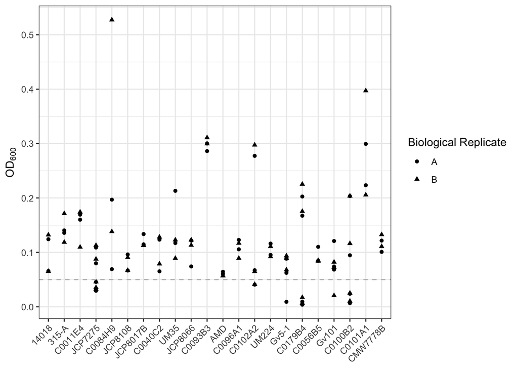

```r
setupDF %>%
  filter(Step=="Mid Log") %>%
  ggplot(aes(x=Strain, y=ODm)) +
  geom_point(aes(shape=BioRep)) +
  geom_hline(aes(yintercept=0.05), linetype=2, color="gray") +
  theme(axis.text.x = element_text(angle=45, hjust=1)) +
  labs(x=NULL, y=bquote(OD[600]), shape="Biological Replicate", color="Experiment Batch")
```

```r
failGrowthSamples <- setupDF %>%
  filter(Step=="Mid Log", ODm<0.05) %>%
  .$Sample

failGrowthSamples
```

```
##  [1] "C0100B2.1B1.A" "C0100B2.1B1.B" "C0100B2.1B2.A" "C0100B2.1B2.B"
##  [5] "C0102A2.1B1.A" "C0102A2.1B2.B" "C0179B4.1B1.A" "C0179B4.1B1.B"
##  [9] "C0179B4.1B2.A" "C0179B4.1B2.B" "Gv101.1B1.B"   "Gv5-1.1A2.A"
## [13] "JCP7275.1B1.A" "JCP7275.1B1.B" "JCP7275.1B2.A" "JCP7275.1B2.B"
## [17] "JCP7275.1B3.A" "JCP7275.1B3.B"
```

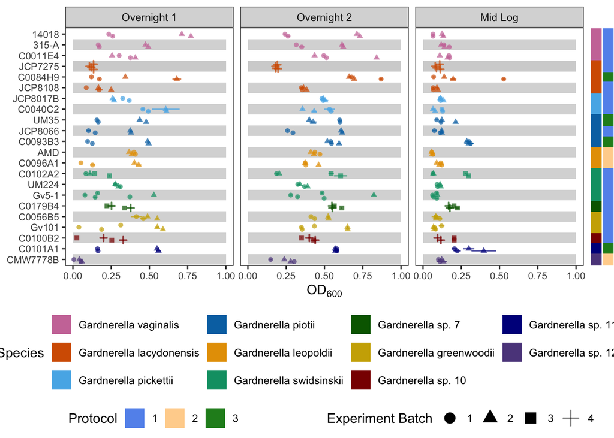

```r
overnightPlot <- setupDF %>%
  filter(Sample %!in% failGrowthSamples) %>%
  ggplot(aes(x=Strain, y=ODm)) +
  geom_rect(aes(xmin=StrainN-.5, xmax=StrainN+.5, ymin = 0, ymax = 1, fill=rectFill), alpha = 0.2, show.legend = FALSE) +
  geom_pointrange(aes(ymin=(ODm-ODsd), ymax=(ODm+ODsd), shape=BatchNum, color=Species), position = position_quasirandom(), size=0.3, alpha=0.7, show.legend = FALSE) +
  geom_point(aes(shape=BatchNum), alpha=0) +
  speciesColor +
  scale_fill_manual(values=c("white", "gray"), labels=c("A","B")) +
  ylim(0,1) +
  facet_grid(.~Step) +
  coord_flip() +
  scale_x_discrete(limits=rev) +
  theme(axis.text.x = element_text(size=8),
        axis.text.y = element_text(size=8),
        axis.title = element_text(size=11),
        panel.grid = element_blank(),
        legend.position = "none") +
  labs(x=NULL, y=bquote(OD[600]), shape="Experiment Batch")

## annotation portions of plot
#protocol bar
protocolBar <- setupDF %>%
  select(Strain, Species, Protocol) %>%
  unique %>%
  mutate(Protocol=as.character(Protocol)) %>%
  ggplot() +
    geom_bar(aes(x=Strain, y=2, fill=Protocol), stat="identity", width = 1.1) +
    scale_x_discrete(limits=rev) +
    scale_fill_manual(values=c("cornflowerblue", "burlywood1", "forestgreen")) +
    coord_flip() +
    theme_void() +
    theme(legend.position = "none")

speciesBar <- setupDF %>%
  select(Strain, Species, Protocol) %>%
  unique %>%
  ggplot() +
    geom_bar(aes(x=Strain, y=1, fill=Species), stat="identity", width=1.1) +
    scale_x_discrete(limits=rev) +
    speciesFill +
    coord_flip() +
    theme_void() +
    theme(legend.position = "none")

#Legends
protocol_legend <- ggpubr::get_legend(
    protocolBar +
    guides(color = guide_legend(nrow = 1)) +
    theme(legend.position = "bottom"))
species_legend <- ggpubr::get_legend(
    speciesBar +
    guides(color=guide_legend(ncol = 1)) +
    theme(legend.position = "bottom"))
experiment_legend <- ggpubr::get_legend(
  overnightPlot +
  guides(shape=guide_legend(nrow = 1, override.aes = list(alpha=1, size=4))) +
  theme(legend.position = "bottom"))

a <- plot_grid(overnightPlot, speciesBar, protocolBar, nrow = 1, align = "h", axis = "bt", rel_widths = c(1, 0.02, 0.02))
b <- plot_grid(a, as_ggplot(species_legend), nrow=2, rel_heights = c(1, 0.3))
c <- plot_grid(as_ggplot(protocol_legend), as_ggplot(experiment_legend), nrow=1)
setUpGrowthFigure <- plot_grid(b, c, ncol=1, nrow=2, rel_heights = c(1, 0.1))
setUpGrowthFigure
```

# Calculate growth in media with lactic acid-adjusted pH

Measured as OD<sub>600</sub> in stationary phase ## Organize data

```r
blankDF <- pH_raw_data %>%
    filter(Number=="Blank")

pH_results_raw <- pH_raw_data %>%
    filter(Number !="Blank")
```

Assess Blanks

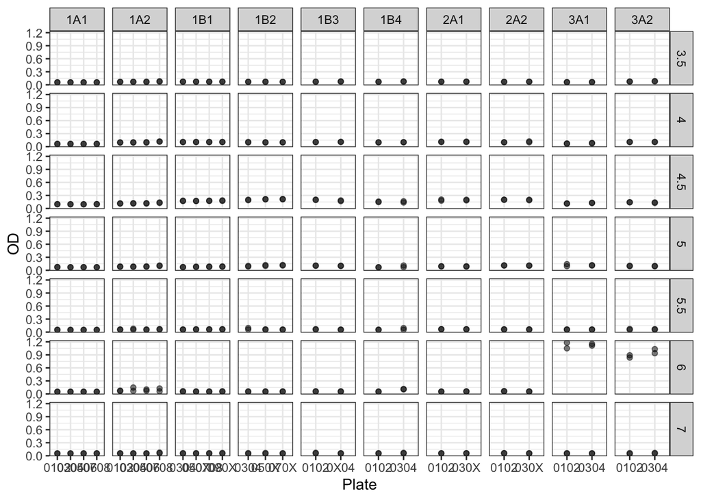

```r
blankDF %>%
  ggplot(aes(x=Plate, y=OD)) +
  geom_point(alpha=0.5) +
  facet_grid(pH~Batch, scales = "free_x")
```

May need to remove pH 6 data from protocol 3 strains.

Perform blank subtraction

```r
meanBlankODs <- blankDF %>%
  with_groups(c(Plate, Batch, pH), summarize, blankOD=mean(OD))


DF0 <- pH_results_raw %>%
  left_join(meanBlankODs) %>%
  mutate(OD=OD-blankOD,
         Species=factor(Species, levels=species),
         Strain=factor(Strain, levels=strains),
         Sample=paste(Batch, Strain, BioRep, sep=".")) %>%
  filter(Sample %!in% failGrowthSamples)
```

Crude assessment of results

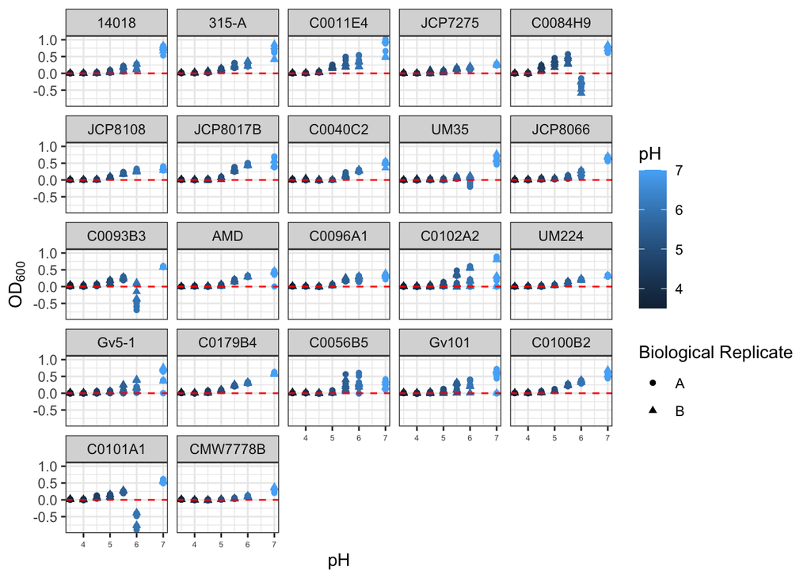

```r
DF0 %>%
  ggplot(aes(x=pH, y=OD, color=pH, shape=BioRep)) +
  geom_point() +
  geom_hline(yintercept = 0, linetype=2, color="red") +
  facet_wrap(~Strain) +
  theme(axis.text.x = element_text(size=5)) +
  labs(x="pH", y=bquote(OD[600]), shape="Biological Replicate")
```

May be some issues with some pH = 7 samples.

Look at issues with low pH 7 results

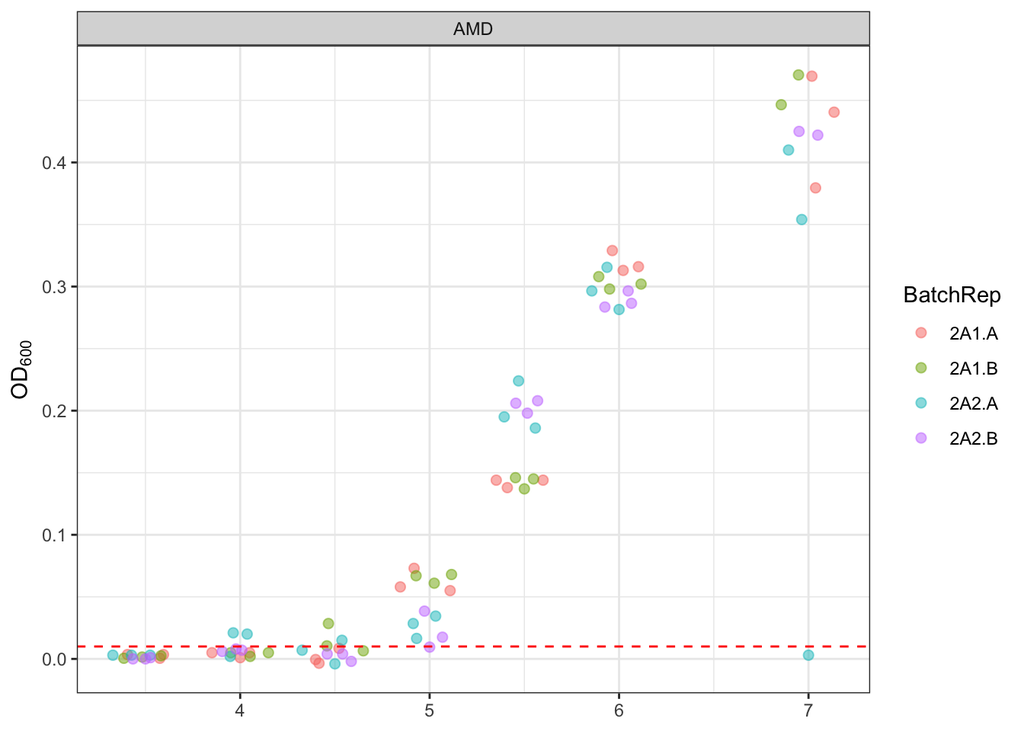

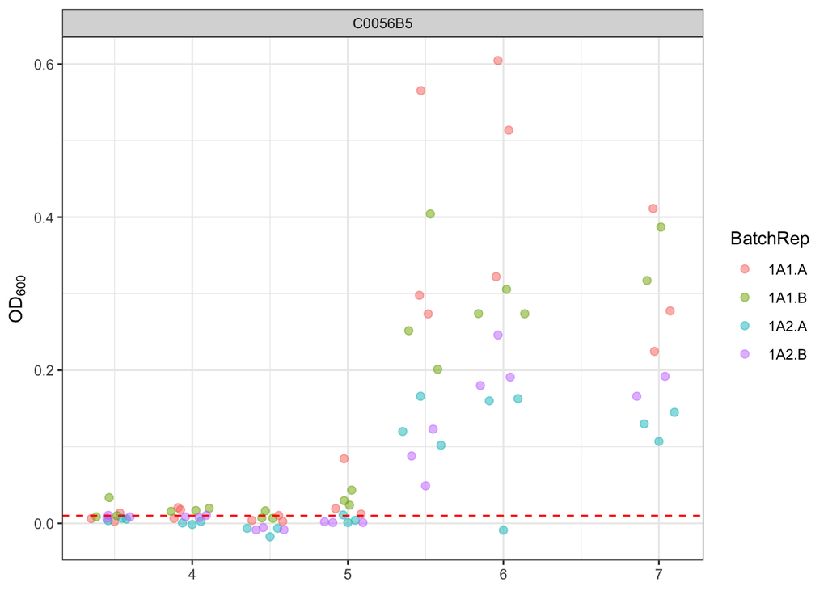

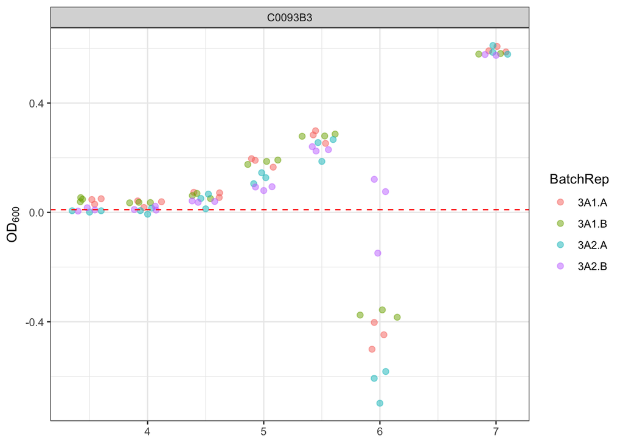

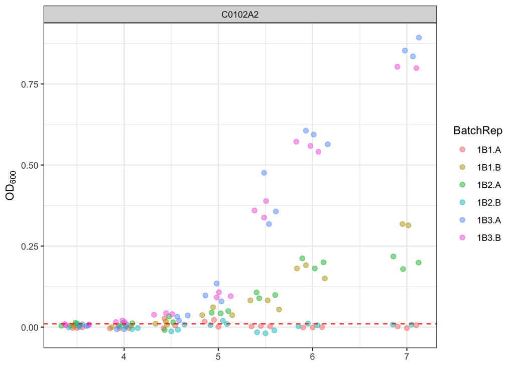

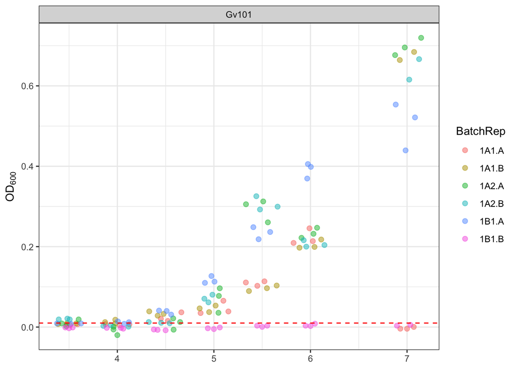

```
##
## $`Gv5-1`
```

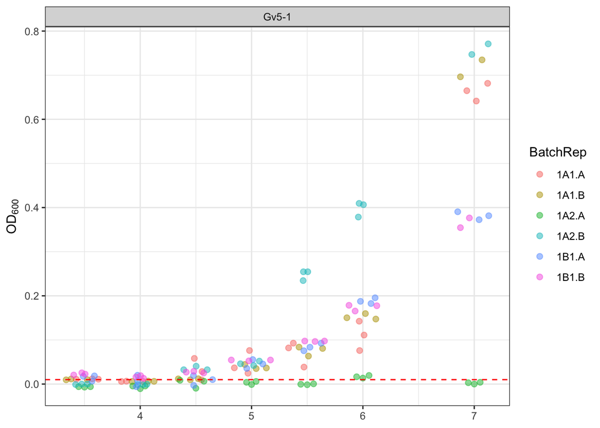

```r
DF0 %>%
  filter(Strain %in% c("AMD", "Gv5-1", "Gv101", "C0102A2", "C0056B5", "C0093B3")) %>%
#         pH==7) %>%
  mutate(PlateSet=str_extract(Batch, "(?<=[A|B])[1|2]"),
         BatchRep=paste(Batch, BioRep, sep="."),
         Strain=as.character(Strain)) %>%
  #ggplot(aes(x=Strain, y=OD, color=BatchRep)) +
  split(.$Strain) %>%
  map(~ggplot(.x, aes(x=pH, y=OD, color=BatchRep)) +
  geom_quasirandom(size=2, alpha=0.5) +
  geom_hline(yintercept = 0.01, linetype=2, color="red") +
  facet_wrap(~Strain) +
  labs(y=bquote(OD[600]), x=NULL))
```

Issues found in: * One technical replicate of AMD * C0102A2 biological replicate A from 1B1, and B from 1B2 * Gv101 biological replicate A from batch 1A1, and B from 1B1 * Gv5-1 Biological replicate A from batch 1A2

```r
filterWells <- DF0 %>%
  filter(pH==7,
         OD<0.01) %>% # samples w
  mutate(SampleWell=paste(Sample, well, sep=".")) %>%
  .$SampleWell
filterWells
```

```
##  [1] "1A1.Gv101.A.H7"   "1A1.Gv101.A.H8"   "1A1.Gv101.A.H9"   "1A2.Gv5-1.A.H1"
##  [5] "1A2.Gv5-1.A.H2"   "1A2.Gv5-1.A.H3"   "1B1.C0102A2.A.H1" "1B1.C0102A2.A.H2"
##  [9] "1B1.C0102A2.A.H3" "1B1.Gv101.B.H4"   "1B1.Gv101.B.H5"   "1B2.C0102A2.B.H4"
## [13] "1B2.C0102A2.B.H5" "2A2.AMD.A.H3"
```

Filter sample with no pH 7 values

```r
filterSamples <- DF0 %>%
  mutate(SampleWell=paste(Sample, well, sep=".")) %>%
  filter(SampleWell %!in% filterWells) %>%
  count(Sample, pH) %>%
  spread(pH, n) %>%
  filter(is.na(`7`)) %>%
  .$Sample
filterSamples
```

```
## [1] "1A1.Gv101.A"   "1A2.Gv5-1.A"   "1B1.C0102A2.A" "1B1.Gv101.B"
## [5] "1B2.C0102A2.B"
```

Filter pH 6 protocol 3

```r
filterpHwells <- DF0 %>%
  mutate(SampleWell=paste(Sample, well, sep=".")) %>%
  filter(SampleWell %!in% filterWells,
         Protocol=="3",
         pH==6) %>%
  unique %>%
  .$SampleWell
filterpHwells
```

```
##  [1] "3A1.C0084H9.A.A6"  "3A1.C0084H9.A.B6"  "3A1.C0084H9.A.C6"
##  [4] "3A1.C0084H9.B.D6"  "3A1.C0084H9.B.E6"  "3A1.C0084H9.B.F6"
##  [7] "3A1.C0101A1.A.A12" "3A1.C0101A1.A.B12" "3A1.C0101A1.A.C12"
## [10] "3A1.C0101A1.B.D12" "3A1.C0101A1.B.E12" "3A1.C0101A1.B.F12"
## [13] "3A1.UM35.A.A6"     "3A1.UM35.A.B6"     "3A1.UM35.A.C6"
## [16] "3A1.UM35.B.D6"     "3A1.UM35.B.E6"     "3A1.UM35.B.F6"
## [19] "3A1.C0093B3.A.A12" "3A1.C0093B3.A.B12" "3A1.C0093B3.A.C12"
## [22] "3A1.C0093B3.B.D12" "3A1.C0093B3.B.E12" "3A1.C0093B3.B.F12"
## [25] "3A2.C0084H9.A.A6"  "3A2.C0084H9.A.B6"  "3A2.C0084H9.A.C6"
## [28] "3A2.C0084H9.B.D6"  "3A2.C0084H9.B.E6"  "3A2.C0084H9.B.F6"
## [31] "3A2.C0101A1.A.A12" "3A2.C0101A1.A.B12" "3A2.C0101A1.A.C12"
## [34] "3A2.C0101A1.B.D12" "3A2.C0101A1.B.E12" "3A2.C0101A1.B.F12"
## [37] "3A2.UM35.A.A6"     "3A2.UM35.A.B6"     "3A2.UM35.A.C6"
## [40] "3A2.UM35.B.D6"     "3A2.UM35.B.E6"     "3A2.UM35.B.F6"
## [43] "3A2.C0093B3.A.A12" "3A2.C0093B3.A.B12" "3A2.C0093B3.A.C12"
## [46] "3A2.C0093B3.B.D12" "3A2.C0093B3.B.E12" "3A2.C0093B3.B.F12"
```

Create final data frame

```r
DF1 <- DF0 %>%
  mutate(SampleWell=paste(Sample, well, sep=".")) %>%
  filter(SampleWell %!in% filterWells,
         Sample %!in% filterSamples,
         SampleWell %!in% c(filterpHwells, "2A2.AMD.A.H3")) %>% # filter pH 6 protocol 3 and the pH 7 well of AMD that was below 0.01
  mutate(OD=case_when(OD<0.003~0,
                      OD>=0.003~OD)) # measurements below the limit of detection (0.003) become 0
```

Save formatted data

```r
pH_DF_save <- DF1 %>%
  with_groups(c(Number, Species, Strain, pH, Batch, Plate, BioRep), summarize, mOD=mean(OD), sdOD=sd(OD)) %>%
  mutate(pH=as.numeric(pH),
         Sample=paste(Strain, Batch, BioRep, pH, sep=".")) %>%
  select(Sample, Strain, Species, pH, mOD, sdOD)

# write_csv(pH_DF_save, file.path(formattedPhenDataOut, "pH_growth.csv"))
```

Data frame used for testing

```r
DF <- DF1 %>%
  with_groups(c(Number, Species, Strain, pH, Batch, Plate, BioRep, Protocol), summarize, mOD=mean(OD), sdOD=sd(OD))
```

## Plot

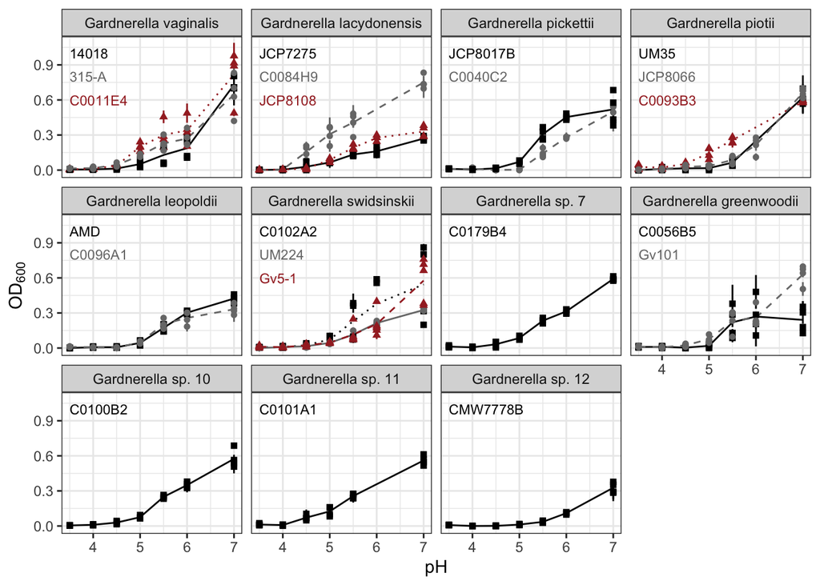

```r
annotationDF <- DF %>%
  filter(pH==7) %>%
  with_groups(c(Species, Strain), summarize, y=mean(mOD)) %>%
  with_groups(Species, mutate, y=1.2-.2*rank(Strain))


pHGrowthPlot <- DF %>%
  mutate(pH=as.numeric(pH)) %>%
  ggplot() +
  stat_summary(aes(x=pH, y=mOD, group=Strain, linetype=Strain, color=Strain), fun="mean", geom = "line", show.legend = FALSE) +
  geom_pointrange(aes(x=pH, y=mOD, ymin=(mOD-sdOD), ymax=(mOD+sdOD), color=Strain, shape=Strain),size=0.3, show.legend = FALSE) +
  geom_text(data=annotationDF, aes(label=Strain, color=Strain, x=3.5, y=y), size=3, show.legend = FALSE, hjust=0) +
  facet_wrap(~Species) +
  scale_shape_manual(values=c(15, 16, 17, 15, 16, 17, 15, 16, 15, 16, 17, 15, 16, 15, 16, 17, 15, 15, 16, 15, 15, 15)) +
  scale_linetype_manual(values=c(1, 2, 3, 1, 2, 3, 1, 2, 1, 2, 3, 1, 2, 3, 1, 2, 1, 1, 2, 1, 1, 1)) +
  scale_color_manual(values=c("black", "gray47", "brown", "black", "gray47", "brown", "black", "gray47", "black", "gray47", "brown", "black", "gray47", "black", "gray47",  "brown", "black", "black", "gray47", "black", "black", "black")) +
  #theme(panel.grid = element_blank()) +
  labs(y=bquote(OD[600]), x="pH")
pHGrowthPlot
```

## Minimum pH with non-zero growth per strain

### T-test

```r
ttest <- DF %>%
  group_by(Species, Strain, pH) %>%
  t_test(mOD~1, mu=0.01, alternative = "greater") %>%
  add_significance("p")
```

```r
minpHtable <- ttest %>%
  group_by(Strain, Species) %>%
  filter(p.signif!="ns") %>%
  filter(pH==min(pH)) %>%
  select(Species, Strain, pH) %>%
  arrange(pH)

minpHtableFigure <- minpHtable %>%
  kbl(caption="Table 1. Minimum pH with growth") %>%
  kable_classic(full_width=TRUE, html_font = "Arial")

minpHtableFigure
```

Table 1. Minimum pH with growth

| Species | Strain | pH |
| --- | --- | --- |
| Gardnerella vaginalis | 315-A | 3.5 |
| Gardnerella vaginalis | C0011E4 | 4.5 |
| Gardnerella lacydonensis | C0084H9 | 4.5 |
| Gardnerella piotii | C0093B3 | 4.5 |
| Gardnerella swidsinskii | Gv5-1 | 4.5 |
| Gardnerella sp. 10 | C0100B2 | 4.5 |
| Gardnerella sp. 11 | C0101A1 | 4.5 |
| Gardnerella vaginalis | 14018 | 5.0 |
| Gardnerella lacydonensis | JCP7275 | 5.0 |
| Gardnerella lacydonensis | JCP8108 | 5.0 |
| Gardnerella pickettii | JCP8017B | 5.0 |
| Gardnerella piotii | JCP8066 | 5.0 |
| Gardnerella leopoldii | AMD | 5.0 |
| Gardnerella leopoldii | C0096A1 | 5.0 |
| Gardnerella swidsinskii | C0102A2 | 5.0 |
| Gardnerella swidsinskii | UM224 | 5.0 |
| Gardnerella sp. 7 | C0179B4 | 5.0 |
| Gardnerella greenwoodii | Gv101 | 5.0 |
| Gardnerella pickettii | C0040C2 | 5.5 |
| Gardnerella piotii | UM35 | 5.5 |
| Gardnerella greenwoodii | C0056B5 | 5.5 |
| Gardnerella sp. 12 | CMW7778B | 5.5 |

```r
#save_kable(minpHtableFigure, file = file.path(figureOut, paste(Sys.Date(), "Table1_minpHTable.png", sep="_")), zoom=6)
```

## Compare growth at pHs

### Isolate Anova

#### One-way Anovas

```r
DF %>%
  select(Species, Strain, Protocol, pH, mOD, sdOD) %>%
  group_by(pH) %>%
  anova_test(mOD~Strain) %>%
  formattable()
```

pH

Effect

DFn

DFd

F

p

p<.05

ges

3.5

Strain

21

67

4.158

4.32e-06

0.566

4.0

Strain

21

67

2.082

1.30e-02

0.395

4.5

Strain

21

67

13.511

1.25e-16

0.809

5.0

Strain

21

67

27.251

5.81e-25

0.895

5.5

Strain

21

67

6.659

1.17e-09

0.676

6.0

Strain

17

55

3.640

1.39e-04

0.529

7.0

Strain

21

67

7.771

5.01e-11

0.709

#### Tukey’s HSD

```r
odPostHocs <- DF %>%
  select(Species, Strain, Protocol, pH, mOD, sdOD) %>%
  group_by(pH) %>%
  tukey_hsd(mOD~Strain, p.adjust.method = "BH")

#save posthoc test results in supplementary tables file
# suppl_xlsx <- loadWorkbook(suppTableOut)
# addWorksheet(suppl_xlsx, "TablesS7_pH_posthocs")
#
# odPostHocs %>%
#  arrange(pH, p.adj) %>%
#  writeData(suppl_xlsx, x=.,  sheet="TablesS7_pH_posthocs")
#
# saveWorkbook(suppl_xlsx, suppTableOut, overwrite = TRUE)
```

Plot pairwise post-hoc results

```r
pHODpvals <- odPostHocs %>%
  split(.$pH) %>%
  map(~select(.x, group1, group2, p.adj)) %>%
  map(~dplyr::rename(.x, var1=group2, var2=group1, cor=p.adj)) %>%
  map(cor_spread) %>%
  map(~column_to_rownames(.x, var="rowname")) %>%
  map(as.matrix)

pHODcorplotInput <-  odPostHocs %>%
  split(.$pH) %>%
  map(~select(.x, group1, group2, estimate)) %>%
  map(~dplyr::rename(.x, var1=group2, var2=group1, cor=estimate)) %>%
  map(cor_spread) %>%
  map(~column_to_rownames(.x, var="rowname")) %>%
  map(as.matrix)

makeCorrPlots <- function(inputMatrix, pvalMatrix) {
  dev.new()
  par(xpd = NA, # switch off clipping, necessary to always see axis labels
  bg = "transparent", # switch off background to avoid obscuring adjacent plots
  oma = c(2, 2, 0, 0)) # move plot to the right and up
  corrplot(inputMatrix, is.corr=FALSE, type = "lower", tl.col="black", p.mat = pvalMatrix, insig = "label_sig", sig.level = c(0.001, 0.01, 0.05), pch.cex = 0.9)
  grid.echo()
  plot <- grid.grab()
  dev.off()
  return(plot)
}

pHODcorrPlots <- map2(pHODcorplotInput, pHODpvals, makeCorrPlots)
```

```r
ratioDF <- DF %>%
  select(-sdOD) %>%
  spread(pH, mOD) %>%
  mutate_at(vars("3.5", "4", "4.5", "5", "5.5", "6", "7"), ~.x/`7`) %>%
  gather("pH", "ratio", c("3.5", "4", "4.5", "5", "5.5", "6", "7"))
```

## Plot

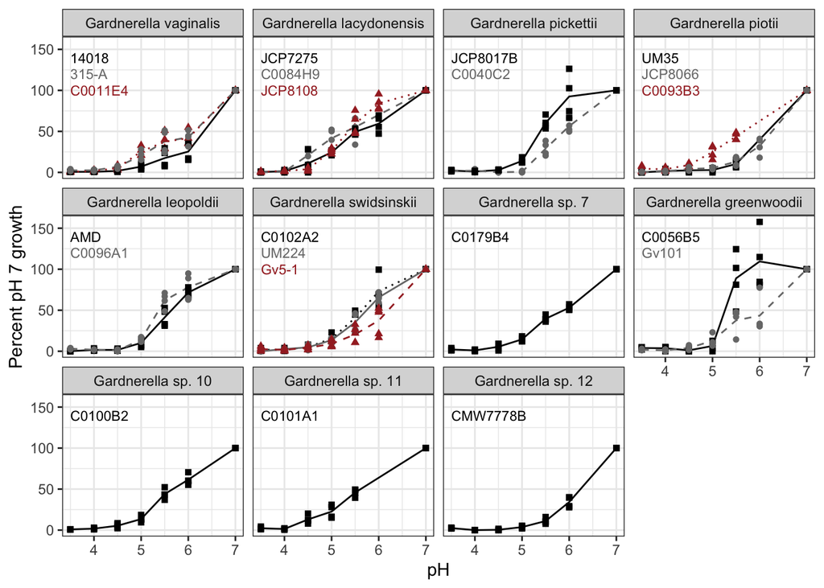

```r
annotationDFratio <- DF %>%
  filter(pH==7) %>%
  with_groups(c(Species, Strain), summarize, y=mean(mOD)) %>%
  with_groups(Species, mutate, y=160-20*rank(Strain))

pHratioPlot <- ratioDF %>%
  mutate(pH=as.numeric(pH),
         percent=ratio*100) %>%
  ggplot() +
  stat_summary(aes(x=pH, y=percent, group=Strain, linetype=Strain, color=Strain), fun="mean", geom = "line", show.legend = FALSE) +
  geom_point(aes(x=pH, y=percent, color=Strain, shape=Strain), show.legend = FALSE) +
  geom_text(data=annotationDFratio, aes(label=Strain, color=Strain, x=3.5, y=y), size=3, show.legend = FALSE, hjust=0) +
  facet_wrap(~Species) +
  scale_shape_manual(values=c(15, 16, 17, 15, 16, 17, 15, 16, 15, 16, 17, 15, 16, 15, 16, 17, 15, 15, 16, 15, 15, 15)) +
  scale_linetype_manual(values=c(1, 2, 3, 1, 2, 3, 1, 2, 1, 2, 3, 1, 2, 3, 1, 2, 1, 1, 2, 1, 1, 1)) +
  scale_color_manual(values=c("black", "gray47", "brown", "black", "gray47", "brown", "black", "gray47", "black", "gray47", "brown", "black", "gray47", "black", "gray47",  "brown", "black", "black", "gray47", "black", "black", "black")) +
  labs(y="Percent pH 7 growth", x="pH")
pHratioPlot
```

## Compare

### Average proportion pH 7 growth at each pH

```r
ratioDF %>%
  filter(pH!=7) %>%
  with_groups(pH, summarize, perc=mean(ratio, na.rm=TRUE)*100)
```

```
## # A tibble: 6 × 2
##   pH     perc
##   <chr> <dbl>
## 1 3.5    1.62
## 2 4      1.69
## 3 4.5    5.19
## 4 5     14.9
## 5 5.5   39.7
## 6 6     58.7
```

### Average OD at low pH with significant strains only

```r
pH3.5_4Strains <- minpHtable %>%
  filter(pH<4.5) %>%
  mutate(Strain=as.character(Strain)) %>%
  .$Strain

pH4.5Strains <- minpHtable %>%
  filter(pH<5) %>%
  mutate(Strain=as.character(Strain)) %>%
  .$Strain
```

Average ratio of pH 7 growth at each pH of 315-A

```r
DF %>%
  select(-sdOD) %>%
  filter(Strain %in% pH3.5_4Strains) %>% # 315-A only
  spread(pH, mOD) %>%
  mutate_at(vars("3.5", "4", "4.5", "5", "5.5", "6", "7"), ~.x/`7`) %>%
  gather("pH", "ratio", c("3.5", "4", "4.5", "5", "5.5", "6", "7")) %>%
  filter(pH!=7) %>%
  with_groups(pH, summarize, perc=mean(ratio, na.rm=TRUE)*100)
```

```
## # A tibble: 6 × 2
##   pH     perc
##   <chr> <dbl>
## 1 3.5    2.47
## 2 4      2.53
## 3 4.5    6.85
## 4 5     20.4
## 5 5.5   37.6
## 6 6     42.7
```

Ratios of pH 7 growth at pH 4.5 of surviving strains

```r
DF %>%
  select(-sdOD) %>%
  filter(Strain %in% pH4.5Strains) %>% # 315-A only
  filter(pH %in% c(4.5, 7)) %>%
  spread(pH, mOD) %>%
  mutate(ratio4.5=`4.5`/`7`*100) %>%
  with_groups(Strain, summarize, mean=mean(ratio4.5), sd=sd(ratio4.5))
```

```
## # A tibble: 7 × 3
##   Strain   mean    sd
##   <fct>   <dbl> <dbl>
## 1 315-A    6.85  1.68
## 2 C0011E4  5.34  2.76
## 3 C0084H9 21.0   8.10
## 4 C0093B3  8.97  2.15
## 5 Gv5-1    4.19  2.26
## 6 C0100B2  5.32  2.81
## 7 C0101A1 13.0   5.11
```

### Isolate Anova

#### One-way Anovas

```r
ratioDF %>%
  filter(pH!="7") %>%
  select(Species, Strain, Protocol, pH,ratio) %>%
  group_by(pH) %>%
  anova_test(ratio~Strain) %>%
  formattable()
```

pH

Effect

DFn

DFd

F

p

p<.05

ges

3.5

Strain

21

67

4.175

4.06e-06

0.567

4

Strain

21

67

1.958

2.00e-02

0.380

4.5

Strain

21

67

6.137

5.68e-09

0.658

5

Strain

21

67

14.400

2.44e-17

0.819

5.5

Strain

21

67

10.718

3.67e-14

0.771

6

Strain

17

55

8.993

1.86e-10

0.735

#### Tukey’s HSD

```r
ratioPostHocs <- ratioDF %>%
  filter(pH!="7") %>%
  select(Species, Strain, Protocol, pH,ratio) %>%
  group_by(pH) %>%
  tukey_hsd(ratio~Strain, p.adjust.method = "BH")

#save posthoc test results in supplementary tables file
# suppl_xlsx <- loadWorkbook(suppTableOut)
# addWorksheet(suppl_xlsx, "TablesS8_pH_ratio_posthocs")
#
# ratioPostHocs %>%
#  arrange(pH, p.adj) %>%
#  writeData(suppl_xlsx, x=.,  sheet="TablesS8_pH_ratio_posthocs")
#
# saveWorkbook(suppl_xlsx, suppTableOut, overwrite = TRUE)
```

Plot pairwise post-hoc results

```r
pHratiopvals <- ratioPostHocs %>%
  filter(pH!="7") %>%
  split(.$pH) %>%
  map(~select(.x, group1, group2, p.adj)) %>%
  map(~dplyr::rename(.x, var1=group2, var2=group1, cor=p.adj)) %>%
  map(cor_spread) %>%
  map(~column_to_rownames(.x, var="rowname")) %>%
  map(as.matrix)

pHratiocorplotInput <-  ratioPostHocs %>%
  filter(pH!="7") %>%
  split(.$pH) %>%
  map(~select(.x, group1, group2, estimate)) %>%
  map(~dplyr::rename(.x, var1=group2, var2=group1, cor=estimate)) %>%
  map(cor_spread) %>%
  map(~column_to_rownames(.x, var="rowname")) %>%
  map(as.matrix)

pHratiocorrPlots <- map2(pHratiocorplotInput, pHratiopvals, makeCorrPlots)
```

# Figure 5: Growth at varying pH’s

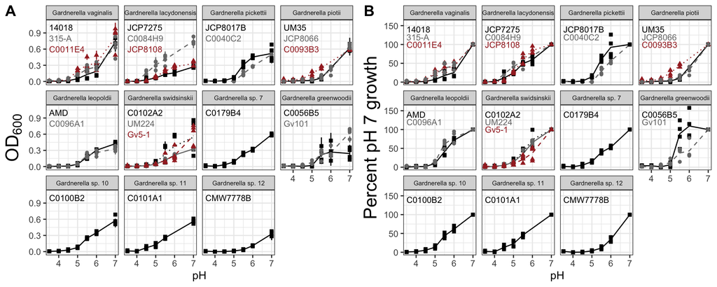

```r
plot_grid(pHGrowthPlot+theme(axis.title.y = element_text(size=18), strip.text.x = element_text(size=6.4)), pHratioPlot+theme(axis.title.y = element_text(size=18), strip.text.x = element_text(size=6.4)), labels = c("A", "B"), label_size = 15)
```

```r
#ggsave(filename = file.path(figureOut, paste(Sys.Date(), "Figure5_pHGrowth.png", sep = "_")))
```

# Figure S4: Post Hoc Test Results

```r
ODPostHocPlots <- plot_grid(pHODcorrPlots$`3.5`, pHODcorrPlots$`4`, pHODcorrPlots$`4.5`, pHODcorrPlots$`5`, pHODcorrPlots$`5.5`, pHODcorrPlots$`6`, pHODcorrPlots$`7`, ncol=1,  labels = c("A", "C", "E", "G", "I", "K", "M"), label_size = 20)

ratioPostHocPlots <- plot_grid(pHratiocorrPlots$`3.5`, pHratiocorrPlots$`4`,pHratiocorrPlots$`4.5`, pHratiocorrPlots$`5`, pHratiocorrPlots$`5.5`, pHratiocorrPlots$`6`, ggplot+geom_blank(),  ncol=1, labels = c("B", "D", "F", "H",  "J",  "L", " "), label_size = 20)

plot_grid(ODPostHocPlots,
          ratioPostHocPlots,
          ncol=2, align = "hv")
#ggsave(file.path(figureOut, paste(Sys.Date(), "FigureS4_pH_posthocs.png", sep = "_")))
```

[figure not shown]